# Métodos Multivariados: Parcial 2

Author

Mateo De La Roche

```r
library(stats)
library(MASS)
library(kernlab)
library(caret)
library(robustbase)
library(ggplot2)
library(MASS)
library(psych)
library(klaR)
set.seed(190748)
```

## Ejercicio 1

El conjunto de datos `Harman23.cor` en el paquete `datasets` es una matriz de correlación de 8 medidas físicas tomadas en 305 niñas con edades entre 7 y 17 años. a. Realiza un análisis de factores de estos datos usando factanal(factors = m, covmat = Harman23.cor) donde m es el número de factores.

```r
data("Harman23.cor", package = "datasets")

fa_result <- factanal(covmat = Harman23.cor, factors = 2, rotation = "varimax")
(fa_result)
```

```
Call:
factanal(factors = 2, covmat = Harman23.cor, rotation = "varimax")

Uniquenesses:
        height       arm.span        forearm      lower.leg         weight
         0.170          0.107          0.166          0.199          0.089
bitro.diameter    chest.girth    chest.width
         0.364          0.416          0.537

Loadings:
               Factor1 Factor2
height         0.865   0.287
arm.span       0.927   0.181
forearm        0.895   0.179
lower.leg      0.859   0.252
weight         0.233   0.925
bitro.diameter 0.194   0.774
chest.girth    0.134   0.752
chest.width    0.278   0.621

               Factor1 Factor2
SS loadings      3.335   2.617
Proportion Var   0.417   0.327
Cumulative Var   0.417   0.744

Test of the hypothesis that 2 factors are sufficient.
The chi square statistic is 75.74 on 13 degrees of freedom.
The p-value is 6.94e-11
```

```r
#cortest.bartlett(Harman23.cor, n = 305)
```

```r
factanal(covmat = Harman23.cor, factors = 3, rotation = "varimax")
```

```
Call:
factanal(factors = 3, covmat = Harman23.cor, rotation = "varimax")

Uniquenesses:
        height       arm.span        forearm      lower.leg         weight
         0.127          0.005          0.193          0.157          0.090
bitro.diameter    chest.girth    chest.width
         0.359          0.411          0.490

Loadings:
               Factor1 Factor2 Factor3
height          0.886   0.267  -0.130
arm.span        0.937   0.195   0.280
forearm         0.874   0.188
lower.leg       0.877   0.230  -0.145
weight          0.242   0.916  -0.106
bitro.diameter  0.193   0.777
chest.girth     0.137   0.755
chest.width     0.261   0.646   0.159

               Factor1 Factor2 Factor3
SS loadings      3.379   2.628   0.162
Proportion Var   0.422   0.329   0.020
Cumulative Var   0.422   0.751   0.771

Test of the hypothesis that 3 factors are sufficient.
The chi square statistic is 22.81 on 7 degrees of freedom.
The p-value is 0.00184
```

2. Varía el número de factores para encontrar un ajuste adecuado del modelo e interpretar las cargas de los factores resultantes.

```r
factanal(covmat = Harman23.cor, factors = 4, rotation = "varimax")
```

```
Call:
factanal(factors = 4, covmat = Harman23.cor, rotation = "varimax")

Uniquenesses:
        height       arm.span        forearm      lower.leg         weight
         0.137          0.005          0.191          0.116          0.138
bitro.diameter    chest.girth    chest.width
         0.283          0.178          0.488

Loadings:
               Factor1 Factor2 Factor3 Factor4
height          0.879   0.277          -0.115
arm.span        0.937   0.194           0.277
forearm         0.875   0.191
lower.leg       0.887   0.209   0.135  -0.188
weight          0.246   0.882   0.111  -0.109
bitro.diameter  0.187   0.822
chest.girth     0.117   0.729   0.526
chest.width     0.263   0.644           0.141

               Factor1 Factor2 Factor3 Factor4
SS loadings      3.382   2.595   0.323   0.165
Proportion Var   0.423   0.324   0.040   0.021
Cumulative Var   0.423   0.747   0.787   0.808

Test of the hypothesis that 4 factors are sufficient.
The chi square statistic is 4.63 on 2 degrees of freedom.
The p-value is 0.0988
```

Parece ser que el ajuste adecuado del modelo se da cuando elegimos 4 factores ya que tenemos una buena proporción de varianza acumulada y también y p-value relativamente alto.

Primer factor: height, arm.span, forearm, lower.leg segundo factor: weight, bitro.diameter, chest.grid tercer factor: chest.grid, lower.leg, weight cuarto factor: chest.width, arm.span

Parece que los diferentes factores nos dicen diferentes proporciones en partes del cuerpo, cuales son las medidas que cada proporción contiene.

```r
Harman23.cor
```

```
$cov
               height arm.span forearm lower.leg weight bitro.diameter
height          1.000    0.846   0.805     0.859  0.473          0.398
arm.span        0.846    1.000   0.881     0.826  0.376          0.326
forearm         0.805    0.881   1.000     0.801  0.380          0.319
lower.leg       0.859    0.826   0.801     1.000  0.436          0.329
weight          0.473    0.376   0.380     0.436  1.000          0.762
bitro.diameter  0.398    0.326   0.319     0.329  0.762          1.000
chest.girth     0.301    0.277   0.237     0.327  0.730          0.583
chest.width     0.382    0.415   0.345     0.365  0.629          0.577
               chest.girth chest.width
height               0.301       0.382
arm.span             0.277       0.415
forearm              0.237       0.345
lower.leg            0.327       0.365
weight               0.730       0.629
bitro.diameter       0.583       0.577
chest.girth          1.000       0.539
chest.width          0.539       1.000

$center
[1] 0 0 0 0 0 0 0 0

$n.obs
[1] 305
```

```r
Harman23.cor
```

```
$cov
               height arm.span forearm lower.leg weight bitro.diameter
height          1.000    0.846   0.805     0.859  0.473          0.398
arm.span        0.846    1.000   0.881     0.826  0.376          0.326
forearm         0.805    0.881   1.000     0.801  0.380          0.319
lower.leg       0.859    0.826   0.801     1.000  0.436          0.329
weight          0.473    0.376   0.380     0.436  1.000          0.762
bitro.diameter  0.398    0.326   0.319     0.329  0.762          1.000
chest.girth     0.301    0.277   0.237     0.327  0.730          0.583
chest.width     0.382    0.415   0.345     0.365  0.629          0.577
               chest.girth chest.width
height               0.301       0.382
arm.span             0.277       0.415
forearm              0.237       0.345
lower.leg            0.327       0.365
weight               0.730       0.629
bitro.diameter       0.583       0.577
chest.girth          1.000       0.539
chest.width          0.539       1.000

$center
[1] 0 0 0 0 0 0 0 0

$n.obs
[1] 305
```

```r
eigen_values <- eigen(Harman23.cor$cov)
(eigen_values$values)
```

```
[1] 4.67287960 1.77098284 0.48103549 0.42144078 0.23322126 0.18667352 0.13730387
[8] 0.09646264
```

```r
(eigen_values$vectors)
```

```
           [,1]       [,2]        [,3]        [,4]       [,5]        [,6]
[1,] -0.3975776 -0.2797405 -0.10138153  0.10746039  0.4083654 -0.15193375
[2,] -0.3893198 -0.3314202  0.11314530 -0.06809937 -0.3409230 -0.07209702
[3,] -0.3761601 -0.3446045  0.01526320  0.04696228 -0.5411895  0.39235508
[4,] -0.3883899 -0.2970667 -0.14497535 -0.12381232  0.4586355 -0.25086379
[5,] -0.3506669  0.3942422 -0.21329349  0.11448967  0.2957297  0.72009856
[6,] -0.3119078  0.4007179 -0.07323449  0.71279966 -0.2194829 -0.40979597
[7,] -0.2855270  0.4359188 -0.42088118 -0.62953051 -0.2571693 -0.25828437
[8,] -0.3102250  0.3144488  0.85303619 -0.22086171  0.1095985 -0.04071268
            [,7]         [,8]
[1,]  0.63598252 -0.384098117
[2,]  0.27848831  0.722612711
[3,] -0.24188344 -0.481639638
[4,] -0.66234538  0.112146116
[5,]  0.02630746  0.237305222
[6,] -0.11197746 -0.006899864
[7,]  0.08024390 -0.125353965
[8,] -0.03303594 -0.116923142
```

```r
var_exp <- eigen_values$values / sum(eigen_values$values)
cum_var_exp <- cumsum(var_exp)
(var_exp)
```

```
[1] 0.58410995 0.22137286 0.06012944 0.05268010 0.02915266 0.02333419 0.01716298
[8] 0.01205783
```

```r
(cum_var_exp)
```

```
[1] 0.5841099 0.8054828 0.8656122 0.9182923 0.9474450 0.9707792 0.9879422
[8] 1.0000000
```

```r
princomp(covmat = Harman23.cor, cor = TRUE)
```

```
Call:
princomp(cor = TRUE, covmat = Harman23.cor)

Standard deviations:
   Comp.1    Comp.2    Comp.3    Comp.4    Comp.5    Comp.6    Comp.7    Comp.8
2.1616844 1.3307828 0.6935672 0.6491847 0.4829299 0.4320573 0.3705454 0.3105844

 8  variables and  305 observations.
```

```r
princomp(covmat = Harman23.cor, cor = FALSE)
```

```
Call:
princomp(cor = FALSE, covmat = Harman23.cor)

Standard deviations:
   Comp.1    Comp.2    Comp.3    Comp.4    Comp.5    Comp.6    Comp.7    Comp.8
2.1616844 1.3307828 0.6935672 0.6491847 0.4829299 0.4320573 0.3705454 0.3105844

 8  variables and  305 observations.
```

No hay diferencia porque ya estamos pasando correlaciones.

## Ejercicio 2

El proyecto SAPA (Synthetic Aperture Personality Assessment) es una colección de datos psicológicos en la web. Un subconjunto de los datos está disonible en el paquete psych como bfi.Este subconjunto contiene datos en tres variables demográficas y 25 atributos de personalidad de 2800 voluntarios. Como ejemplos de estos atributos, se tiene: Yo sé cómo confortar a otros Perdí mi tiempo Hago amigos fácilmente Cada atributo se califica del 1 al 6 dependiendo de si el respondente siente que está de acuerdo con la afirmación en la escala de Likert de completamente de acuerdo (1) o completamente en desacuerdo (6). Ver help(bfi) para más detalles.

1. Usar el comando complete.cases() para quitar a los individuos que tienen algún dato faltante en bfi

```r
data("bfi")

bfi_clean <- bfi[complete.cases(bfi), ]
colnames(bfi_clean)
```

```
 [1] "A1"        "A2"        "A3"        "A4"        "A5"        "C1"
 [7] "C2"        "C3"        "C4"        "C5"        "E1"        "E2"
[13] "E3"        "E4"        "E5"        "N1"        "N2"        "N3"
[19] "N4"        "N5"        "O1"        "O2"        "O3"        "O4"
[25] "O5"        "gender"    "education" "age"
```

2. Usar análisis factorial para agrupar juntos atributos de naturaleza similar. Trata de interpretar la naturaleza de los atributos que se agrupan juntos.

```r
#tomamos solo las columnas de atributos de personalidad
fa_result <- fa(bfi_clean[, 1:25], nfactors=5, rotate="varimax")
fa_result
```

```
Factor Analysis using method =  minres
Call: fa(r = bfi_clean[, 1:25], nfactors = 5, rotate = "varimax")
Standardized loadings (pattern matrix) based upon correlation matrix
     MR2   MR1   MR3   MR5   MR4   h2   u2 com
A1  0.11  0.04  0.03 -0.42 -0.09 0.20 0.80 1.3
A2  0.04  0.22  0.14  0.61  0.04 0.44 0.56 1.4
A3  0.01  0.32  0.11  0.64  0.05 0.53 0.47 1.6
A4 -0.06  0.20  0.22  0.43 -0.13 0.30 0.70 2.2
A5 -0.12  0.38  0.09  0.53  0.05 0.46 0.54 2.0
C1  0.02  0.06  0.54  0.03  0.21 0.34 0.66 1.3
C2  0.09  0.02  0.64  0.11  0.10 0.44 0.56 1.2
C3 -0.03  0.03  0.56  0.11 -0.01 0.33 0.67 1.1
C4  0.24 -0.07 -0.63 -0.03 -0.10 0.47 0.53 1.4
C5  0.28 -0.18 -0.56 -0.04  0.04 0.43 0.57 1.7
E1  0.03 -0.57  0.03 -0.12 -0.06 0.34 0.66 1.1
E2  0.24 -0.68 -0.10 -0.11 -0.05 0.55 0.45 1.4
E3  0.02  0.55  0.09  0.26  0.28 0.46 0.54 2.0
E4 -0.12  0.64  0.10  0.32 -0.08 0.54 0.46 1.7
E5  0.04  0.51  0.32  0.09  0.20 0.42 0.58 2.1
N1  0.79  0.08 -0.04 -0.21 -0.08 0.68 0.32 1.2
N2  0.75  0.04 -0.02 -0.19 -0.01 0.61 0.39 1.1
N3  0.73 -0.06 -0.06 -0.02  0.00 0.55 0.45 1.0
N4  0.59 -0.35 -0.18  0.01  0.08 0.51 0.49 1.9
N5  0.54 -0.16 -0.05  0.11 -0.16 0.35 0.65 1.5
O1 -0.01  0.21  0.12  0.05  0.50 0.32 0.68 1.5
O2  0.18  0.00 -0.10  0.10 -0.48 0.28 0.72 1.5
O3  0.03  0.31  0.07  0.12  0.60 0.48 0.52 1.6
O4  0.22 -0.19 -0.04  0.14  0.37 0.24 0.76 2.7
O5  0.08 -0.01 -0.06 -0.02 -0.54 0.31 0.69 1.1

                       MR2  MR1  MR3  MR5  MR4
SS loadings           2.71 2.49 2.02 1.79 1.54
Proportion Var        0.11 0.10 0.08 0.07 0.06
Cumulative Var        0.11 0.21 0.29 0.36 0.42
Proportion Explained  0.26 0.24 0.19 0.17 0.15
Cumulative Proportion 0.26 0.49 0.68 0.85 1.00

Mean item complexity =  1.5
Test of the hypothesis that 5 factors are sufficient.

df null model =  300  with the objective function =  7.41 with Chi Square =  16484.78
df of  the model are 185  and the objective function was  0.63

The root mean square of the residuals (RMSR) is  0.03
The df corrected root mean square of the residuals is  0.04

The harmonic n.obs is  2236 with the empirical chi square  1046.45  with prob <  3.1e-120
The total n.obs was  2236  with Likelihood Chi Square =  1400.38  with prob <  1.6e-185

Tucker Lewis Index of factoring reliability =  0.878
RMSEA index =  0.054  and the 90 % confidence intervals are  0.052 0.057
BIC =  -26.42
Fit based upon off diagonal values = 0.98
Measures of factor score adequacy
                                                   MR2  MR1  MR3  MR5  MR4
Correlation of (regression) scores with factors   0.92 0.88 0.86 0.84 0.83
Multiple R square of scores with factors          0.85 0.77 0.74 0.70 0.69
Minimum correlation of possible factor scores     0.71 0.54 0.48 0.41 0.38
```

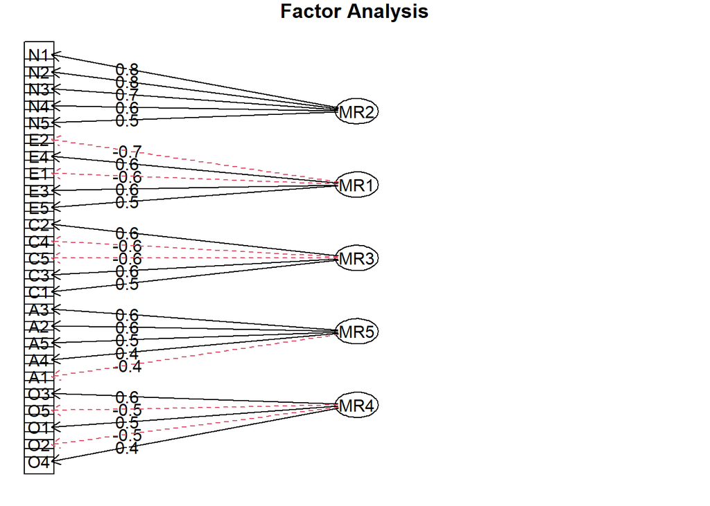

```r
fa.diagram(fa_result)
```

```r
#help(bfi)
```

| A | C | E | N | O |
| --- | --- | --- | --- | --- |
| A1. Am indifferent to the feelings of others. (q_146) | C1. Am exacting in my work. (q_124) | E1. Don’t talk a lot. (q_712) | N1. Get angry easily. (q_952) | O1. Am full of ideas. (q_128) |
| A2. Inquire about others’ well-being. (q_1162) | C2. Continue until everything is perfect. (q_530) | E2. Find it difficult to approach others. (q_901) | N2. Get irritated easily. (q_974) | O2. Avoid difficult reading material. (q_316) |
| A3. Know how to comfort others. (q_1206) | C3. Do things according to a plan. (q_619) | E3. Know how to captivate people. (q_1205) | N3. Have frequent mood swings. (q_1099) | O3. Carry the conversation to a higher level. (q_492) |
| A4. Love children. (q_1364) | C4. Do things in a half-way manner. (q_626) | E4. Make friends easily. (q_1410) | N4. Often feel blue. (q_1479) | O4. Spend time reflecting on things. (q_1738) |
| A5. Make people feel at ease. (q_1419) | C5. Waste my time. (q_1949) | E5. Take charge. (q_1768) | N5. Panic easily. (q_1505) | O5. Will not probe deeply into a subject. (q_1964) |

Podemos ver como los factores se agrupan por la forma en la que el test está diseñado. Factor 1: Ns, estabilidad emocional o cambios de de humor Factor 2: Es, sociabilidad Factor 3: Cs, cosas relacionadas a la forma de trabajar Factor 4: As, preocupación por los demás Factor 5: Os, cosas relacionadas con la forma de pensar

## Ejercicio 3

En tiempos de estrés, el cuerpo pasa por un proceso llamado vaso-constricción en el cual las venas se cierran en las extremidades, forzando la sangre a los órganos centrales. La vaso-constricción puede ocurrir después de tomar un respiro profundo. El conjunto de datos vaso en el paquete robustbase resume la vaso-contricción (o no) de dedos de sujetos a lo largo de sus volúmenes y tasas de respiración.

```r
data(vaso)
vaso
```

```
   Volume  Rate Y
1    3.70 0.825 1
2    3.50 1.090 1
3    1.25 2.500 1
4    0.75 1.500 1
5    0.80 3.200 1
6    0.70 3.500 1
7    0.60 0.750 0
8    1.10 1.700 0
9    0.90 0.750 0
10   0.90 0.450 0
11   0.80 0.570 0
12   0.55 2.750 0
13   0.60 3.000 0
14   1.40 2.330 1
```

[output cut: 25 more lines]

```r
table(vaso$Y)
```

```
 0  1
19 20
```

1. Grafica las tasas de respiración y los volúmenes usando diferentes colores para aquellos con y sin vaso-constricción. Aplica LDA para ver cómo se distinguen los dos grupos.

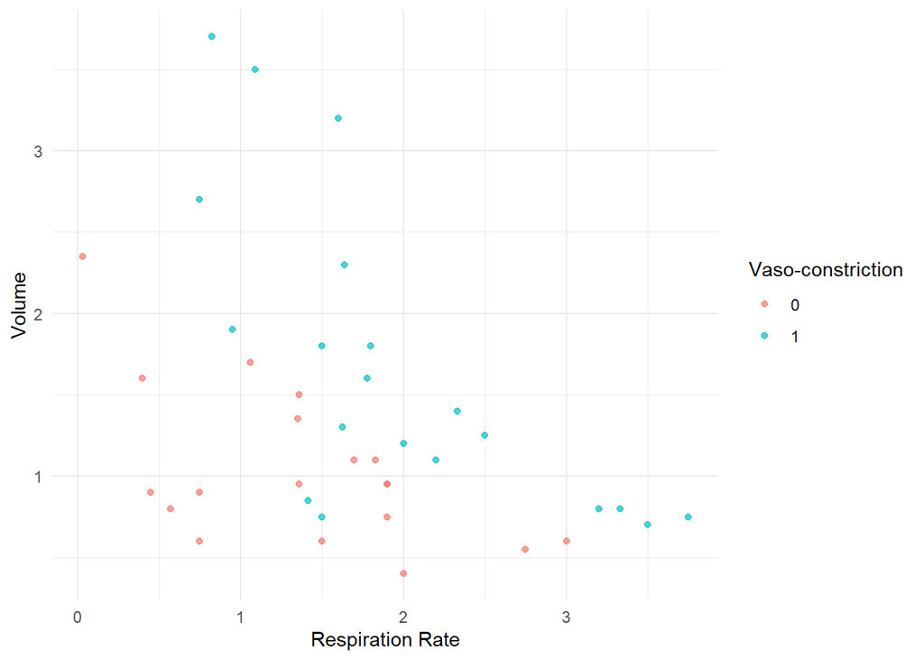

```r
ggplot(vaso, aes(x = Rate, y = Volume, color = as.factor(Y))) +
  geom_point(alpha = 0.7) +
  labs(color = "Vaso-constriction",
       x = "Respiration Rate",
       y = "Volume") +
  theme_minimal()
```

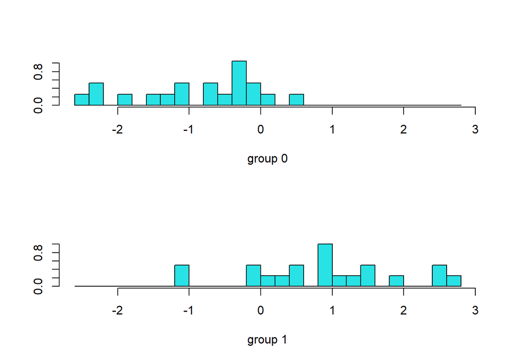

```r
lda_model <- lda(Y ~ Rate + Volume, data = vaso)
plot(lda_model)
```

Podemos ver que si le distinguen pero existe una superposición entre los grupos. Repetir el análisis de la parte (a) pero primero toma logaritmos de las variables explicativas. ¿Qué análisis se prefiere?

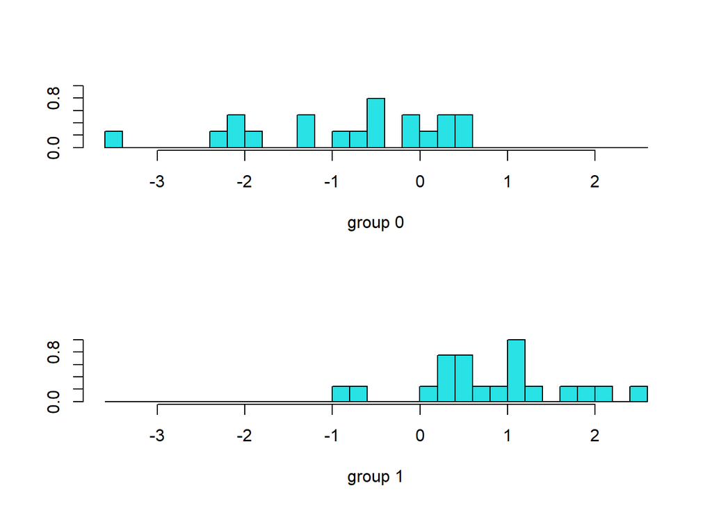

```r
vaso$logRate <- log(vaso$Rate)
vaso$logVolume <- log(vaso$Volume)

lda_model_log <- lda(Y ~ logRate + logVolume, data = vaso)
plot(lda_model_log)
```

Vamos a repetir el análisis pero con la librería partimat.

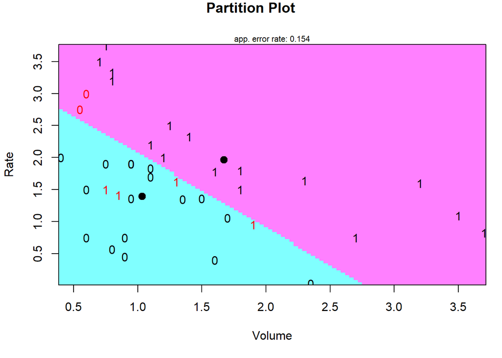

```r
partimat(as.factor(Y) ~ Rate + Volume, data = vaso, method = "lda")
```

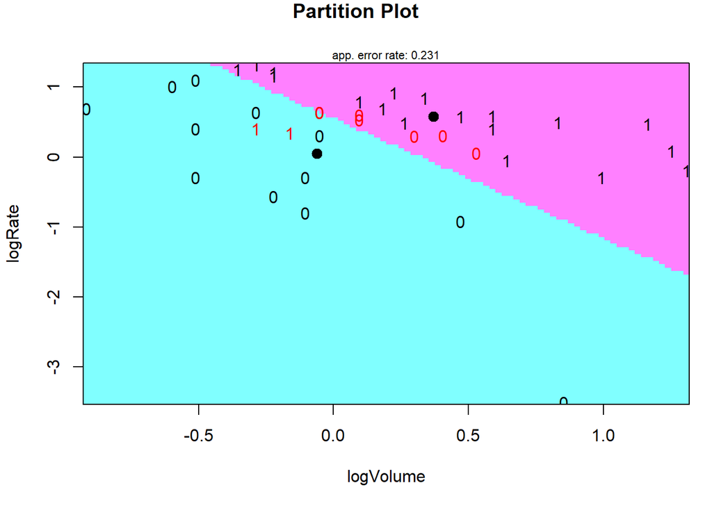

```r
partimat(as.factor(Y) ~ logRate + logVolume, data = vaso, method = "lda")
```

Con partimat podemos ver que al aplicar la transformación, los errores cambian de clase.

## Ejercicio 4

El conjunto de datos musk en el paquete kernlab es un ejemplo de un problema de discriminación en un conjunto de datos grande. En este conjunto de datos hay 476 moléculas: 207 se clasifican como almizcle y las restantes 269 no son almizcle. El objetivo es identificar una clasificación de los almizcles de los no-almizcles usando cualquier combinación de las 166 variables explicativas. Estas variables explicativas miden distancias moleculares en diferentes direcciones. Los datos originales están en https://archive.ics.uci.edu/ml/datasets/Musk+(Version+1) con información adicional que incluye una descripción completa de las variables explicativas.

```r
data(musk)
colnames(musk)
```

```
  [1] "V1"    "V2"    "V3"    "V4"    "V5"    "V6"    "V7"    "V8"    "V9"
 [10] "V10"   "V11"   "V12"   "V13"   "V14"   "V15"   "V16"   "V17"   "V18"
 [19] "V19"   "V20"   "V21"   "V22"   "V23"   "V24"   "V25"   "V26"   "V27"
 [28] "V28"   "V29"   "V30"   "V31"   "V32"   "V33"   "V34"   "V35"   "V36"
 [37] "V37"   "V38"   "V39"   "V40"   "V41"   "V42"   "V43"   "V44"   "V45"
 [46] "V46"   "V47"   "V48"   "V49"   "V50"   "V51"   "V52"   "V53"   "V54"
 [55] "V55"   "V56"   "V57"   "V58"   "V59"   "V60"   "V61"   "V62"   "V63"
 [64] "V64"   "V65"   "V66"   "V67"   "V68"   "V69"   "V70"   "V71"   "V72"
 [73] "V73"   "V74"   "V75"   "V76"   "V77"   "V78"   "V79"   "V80"   "V81"
 [82] "V82"   "V83"   "V84"   "V85"   "V86"   "V87"   "V88"   "V89"   "V90"
 [91] "V91"   "V92"   "V93"   "V94"   "V95"   "V96"   "V97"   "V98"   "V99"
[100] "V100"  "V101"  "V102"  "V103"  "V104"  "V105"  "V106"  "V107"  "V108"
[109] "V109"  "V110"  "V111"  "V112"  "V113"  "V114"  "V115"  "V116"  "V117"
[118] "V118"  "V119"  "V120"  "V121"  "V122"  "V123"  "V124"  "V125"  "V126"
[127] "V127"  "V128"  "V129"  "V130"  "V131"  "V132"  "V133"  "V134"  "V135"
[136] "V136"  "V137"  "V138"  "V139"  "V140"  "V141"  "V142"  "V143"  "V144"
[145] "V145"  "V146"  "V147"  "V148"  "V149"  "V150"  "V151"  "V152"  "V153"
[154] "V154"  "V155"  "V156"  "V157"  "V158"  "V159"  "V160"  "V161"  "V162"
[163] "V163"  "V164"  "V165"  "V166"  "Class"
```

```r
split_indi <- createDataPartition(musk$Class, p = 0.80, list = FALSE)
train <- musk[split_indi,]
test <- musk[-split_indi,]
head(train)
```

```
  V1   V2   V3  V4   V5 V6 V7   V8  V9 V10  V11  V12  V13  V14  V15  V16 V17
1 42 -198 -109 -75 -117 11 23  -88 -28 -27 -232 -212  -66 -286 -287 -300 -57
2 42 -191 -142 -65 -117 55 49 -170 -45   5 -325 -115 -107 -281 -257 -303  54
4 42 -198 -110 -65 -117 55 23  -95 -28   5 -301 -212 -107 -280 -284 -301 -56
5 42 -198 -102 -75 -117 10 24  -87 -28 -28 -233 -212  -67 -286 -286 -299 -57
6 42 -191 -142 -65 -117 55 49 -170 -45   6 -324 -114 -106 -280 -257 -302  54
7 42 -190 -142 -75 -117 12 49 -161 -45 -29 -277 -114  -68 -274 -285 -302  54
   V18  V19  V20 V21 V22 V23 V24 V25 V26 V27  V28 V29 V30  V31  V32 V33 V34
1  -75 -192 -184 -66 -18 -50 111 110  18 -18 -127  25  63 -117 -114 -47   9
2 -154 -101  -47 -31 -28   1 191  72 -38  50  -64 -63  98 -117 -113 -46   2
4  -74 -192  -46 -66 -19 -50 191  73  18 -19 -128 -63  98 -117 -113 -46   3
5  -74 -191 -182 -66 -18 -50 109 111  18 -18 -128  25  63 -117   55 -28  10
6 -153 -100  -47 -30 -28   1 190  73 -38  49  -64 -64  97 -117   56 -28   3
7 -153 -100 -182 -31 -28   0 108 110 -38  50  -65  26  64 -117   61 -31  11
   V35 V36  V37 V38  V39 V40  V41 V42 V43  V44  V45  V46  V47 V48  V49  V50
```

[output cut: 62 more lines]

```r
lda_model <- train(Class ~ .,
                   data = train,
                   method = "lda",
                   metric = "Accuracy",
                   trControl = trainControl(method = "cv"))
lda_model
```

```
Linear Discriminant Analysis

382 samples
166 predictors
  2 classes: '0', '1'

No pre-processing
Resampling: Cross-Validated (10 fold)
Summary of sample sizes: 345, 345, 344, 343, 343, 345, ...
Resampling results:

  Accuracy   Kappa
  0.8163056  0.6303914
```

```r
summary(lda_model)
```

```
            Length Class      Mode
prior         2    -none-     numeric
counts        2    -none-     numeric
means       332    -none-     numeric
scaling     166    -none-     numeric
lev           2    -none-     character
svd           1    -none-     numeric
N             1    -none-     numeric
call          3    -none-     call
xNames      166    -none-     character
problemType   1    -none-     character
tuneValue     1    data.frame list
obsLevels     2    -none-     character
param         0    -none-     list
```

```r
predictions <- predict(lda_model, test)
confusionMatrix(predictions, test$Class)
```

```
Confusion Matrix and Statistics

          Reference
Prediction  0  1
         0 40  7
         1 13 34

               Accuracy : 0.7872
                 95% CI : (0.6907, 0.8649)
    No Information Rate : 0.5638
    P-Value [Acc > NIR] : 4.848e-06

                  Kappa : 0.5745

 Mcnemar's Test P-Value : 0.2636

            Sensitivity : 0.7547
            Specificity : 0.8293
         Pos Pred Value : 0.8511
         Neg Pred Value : 0.7234
             Prevalence : 0.5638
         Detection Rate : 0.4255
   Detection Prevalence : 0.5000
      Balanced Accuracy : 0.7920

       'Positive' Class : 0
```

Coeficientes

```r
lda_model$finalModel$scaling
```

```
               LD1
V1    6.579001e-02
V2   -9.635389e-03
V3   -1.515246e-02
V4   -4.358374e-03
V5   -1.562091e-02
V6   -7.938395e-04
V7   -2.994219e-02
V8    5.261566e-03
V9   -5.209646e-02
V10  -1.922837e-02
V11   4.043021e-03
V12  -5.607102e-02
V13  -1.971794e-02
V14  -2.183334e-02
V15  -9.471292e-03
V16  -1.890813e-04
V17   2.798413e-03
V18  -3.646182e-04
V19  -7.020660e-03
V20   2.483752e-03
V21   5.475518e-03
V22  -6.972567e-02
V23  -2.582972e-02
V24  -5.463223e-03
V25  -1.097900e-02
V26  -4.529930e-02
V27   5.041539e-02
V28   6.971706e-04
V29  -1.821845e-02
V30   1.860569e-02
V31  -8.086391e-03
V32   1.090889e-02
V33   2.125409e-02
V34   3.364265e-03
V35  -7.453186e-03
V36  -1.783678e-02
V37  -3.326483e-03
V38   2.620456e-02
V39  -2.129604e-02
```

[output cut: 112 more lines]

```
V152  4.864558e-03
V153 -5.117244e-03
V154  2.391314e-02
V155 -3.772562e-03
V156 -7.480919e-05
V157 -1.250312e-03
V158 -8.829534e-03
V159  6.741233e-03
V160  7.840879e-03
V161 -1.148481e-02
V162  5.491100e-03
V163  1.705106e-02
V164 -4.313375e-02
V165  2.715201e-02
V166 -5.435486e-03
```

## Ejercicio 5

El conjunto de datos mtcars tiene 11 diferentes atributos sobre autos. Estos atributos son o características diseñadas por ingenieros en la fábrica o atributos empíricos experimentados por el conductor. * Los atributos de diseño son: cyl, disp, carb, drat, gear, vs * Los atributos de experiencia son: mpg, hp, wt, qsec, am

```r
data(mtcars)
diseno <- mtcars[, c("cyl", "disp", "carb", "drat", "gear", "vs")]
experiencia <- mtcars[, c("mpg", "hp", "wt", "qsec", "am")]
```

1. ¿Cómo se pueden combinar los atributos de diseño y mostrar que se relacionan con una combinación de los atributos de experiencia?

```r
corcan <- cancor(diseno, experiencia)
corcan
```

```
$cor
[1] 0.9850787 0.8471577 0.5796657 0.4137175 0.2548956

$xcoef
              [,1]          [,2]         [,3]          [,4]         [,5]
cyl  -0.0100612390 -0.0569725135 -0.189103848  0.2479140068 -0.102007942
disp -0.0009495869  0.0004777465  0.002595693 -0.0012817966 -0.001723557
carb -0.0412607448  0.0209358523  0.085311493  0.0001123744  0.148096201
drat  0.0168545333 -0.1114867476 -0.017162071 -0.0115810636 -0.261447690
gear  0.0092210270 -0.2019148908  0.045291715  0.1449428572 -0.202846030
vs   -0.0031559628  0.2008177747  0.187622423  0.5772281070 -0.162098510
              [,6]
cyl  -0.0389624753
disp  0.0002254826
carb -0.0679174163
drat -0.5075998495
gear  0.3172873054
vs   -0.0705387787

$ycoef
              [,1]          [,2]        [,3]         [,4]         [,5]
mpg  -0.0006532741 -0.0009491906 0.012578147 -0.009797823 -0.077407171
hp   -0.0008829583 -0.0003685299 0.002683266  0.005001656 -0.001609325
wt   -0.1051231423  0.0258415492 0.163035807 -0.353350819 -0.189553488
qsec  0.0277569776  0.0550748950 0.129469152  0.103853140  0.072405438
am    0.0317021519 -0.2174647296 0.430690734 -0.194815128  0.333154777

$xcenter
       cyl       disp       carb       drat       gear         vs
  6.187500 230.721875   2.812500   3.596563   3.687500   0.437500

$ycenter
      mpg        hp        wt      qsec        am
 20.09062 146.68750   3.21725  17.84875   0.40625
```

para esto nos podemos fijar en los coeficientes de las correlaciones canónicas.

```r
corcan$xcoef
```

```
              [,1]          [,2]         [,3]          [,4]         [,5]
cyl  -0.0100612390 -0.0569725135 -0.189103848  0.2479140068 -0.102007942
disp -0.0009495869  0.0004777465  0.002595693 -0.0012817966 -0.001723557
carb -0.0412607448  0.0209358523  0.085311493  0.0001123744  0.148096201
drat  0.0168545333 -0.1114867476 -0.017162071 -0.0115810636 -0.261447690
gear  0.0092210270 -0.2019148908  0.045291715  0.1449428572 -0.202846030
vs   -0.0031559628  0.2008177747  0.187622423  0.5772281070 -0.162098510
              [,6]
cyl  -0.0389624753
disp  0.0002254826
carb -0.0679174163
drat -0.5075998495
gear  0.3172873054
vs   -0.0705387787
```

```r
corcan$ycoef
```

```
              [,1]          [,2]        [,3]         [,4]         [,5]
mpg  -0.0006532741 -0.0009491906 0.012578147 -0.009797823 -0.077407171
hp   -0.0008829583 -0.0003685299 0.002683266  0.005001656 -0.001609325
wt   -0.1051231423  0.0258415492 0.163035807 -0.353350819 -0.189553488
qsec  0.0277569776  0.0550748950 0.129469152  0.103853140  0.072405438
am    0.0317021519 -0.2174647296 0.430690734 -0.194815128  0.333154777
```

2. ¿Cuál es la importancia relativa de cada atributo de diseño en crear la experiencia del conductor?

3. ¿Cuál experiencia del conductor domina o resume a las otras?

La que tiene los coeficientes más altos es am.

4. ¿Cuáles son los autos que aparecen al principio o al final de estas escalas?

```r
scores_diseno <- as.matrix(diseno) %*% corcan$xcoef
scores_exp <- as.matrix(experiencia) %*% corcan$ycoef


scores <- data.frame(Diseno = scores_diseno[, 1],
                     Experiencia = scores_exp[, 1])


scores$car <- rownames(mtcars)


autos_inicial <- head(scores[order(scores$Diseno), ], 5)
autos_final <- head(scores[order(-scores$Experiencia), ], 5)
```

```r
autos_inicial
```

```
                        Diseno Experiencia                 car
Cadillac Fleetwood  -0.6166910  -0.2406265  Cadillac Fleetwood
Lincoln Continental -0.6041162  -0.2721887 Lincoln Continental
Maserati Bora       -0.5906313  -0.2439257       Maserati Bora
Chrysler Imperial   -0.5812479  -0.2910402   Chrysler Imperial
Duster 360          -0.5056180  -0.1612857          Duster 360
```

```r
autos_final
```

```
                    Diseno Experiencia            car
Toyota Corolla -0.04416705   0.3116268 Toyota Corolla
Honda Civic    -0.07782918   0.3102141    Honda Civic
Fiat X1-9      -0.05402842   0.2767861      Fiat X1-9
Fiat 128       -0.05374355   0.2614183       Fiat 128
Lotus Europa   -0.10658139   0.2221099   Lotus Europa
```